# Distribution of phylogenetic contrasts under OU model

Qing (Sabrina) Yu and Cecile Ane

August 22, 2016

# Goal of the study

# Simulation procedure

We used the lizard tree from the `phylolm` package and associated trait data on these lizard species (just the first trait, which is the first PC axis from a PCA). This trait was analyzed to estimate the shifts in trait evolution using the function `estimate_shift_configuration` from the `l1ou` package. The analysis takes about 2 minutes, so the results were saved in an R data file:

```r
data(lizard.tree, lizard.traits)
lizard <- adjust_data(lizard.tree, lizard.traits[,1])
eModel <- estimate_shift_configuration(lizard$tree, lizard$Y)
save(eModel,  file = "eModel.RData")
```

The estimated shift configuration can be loaded quickly now:

```r
load("eModel.RData")
```

Next, variables are set up to prepare the simulation.

```r
truealpha=eModel$alpha
y0=eModel$intercept
truetheta = y0 + l1ou:::convert_shifts2regions(eModel$tree,
                                eModel$shift.configuration, eModel$shift.values)
nShifts   = length(eModel$shift.configuration) # Total number of shifts
n_tips=length(eModel$tree$tip.label) # Total number of tips
sigma2=eModel$sigma2
shiftnode= eModel$tree$edge[eModel$shift.configuration,1]-n_tips # internal nodes with shift
othernode=(1:(n_tips-1))[-shiftnode] # Other nodes: those without a true shift
```

The tree has $100$ tips and $8$ nodes with a shift at one of its child edges, numbered $72, 51, 41, 63, 93, 61, 84, 18$ (`shiftnode`). At these shifts, the optimal value changed by: -2.91, -2.97, -5.5, -2.39, -2.61, -1.91, -3.7, -3.49 (shift values). The other parameters were estimated to be $\alpha=$ $0.606898$ (`truealpha`) and $\sigma^2=$ $0.0625187$ and an “intercept” `y0` of $0.2488096$. Together with the changes, this intercept gives the following optimal values `truetheta`, one for each edge: $\theta=$ 0.25, 0.25, 0.25, 0.25, 0.25, 0.25, 0.25, 0.25, 0.25, 0.25, 0.25, 0.25, 0.25, -2.36, 0.25, 0.25, 0.25, 0.25, 0.25, 0.25, 0.25, 0.25, 0.25, 0.25, 0.25, 0.25, 0.25, 0.25, 0.25, 0.25, 0.25, -3.45, 0.25, 0.25, 0.25, 0.25, 0.25, 0.25, 0.25, 0.25, 0.25, 0.25, 0.25, 0.25, 0.25, 0.25, 0.25, 0.25, -1.66, -1.66, -1.66, -1.66, -4.57, -4.57, -4.57, -1.66, -1.66, -1.66, -1.66, -1.66, -1.66, -1.66, -1.66, -1.66, -1.66, -1.66, -1.66, -1.66, -1.66, -1.66, -1.66, -1.66, -1.66, -4.05, -1.66, -1.66, -1.66, 0.25, 0.25, 0.25, -2.72, -2.72, -2.72, -2.72, -2.72, -2.72, 0.25, 0.25, 0.25, 0.25, 0.25, 0.25, 0.25, 0.25, 0.25, 0.25, 0.25, -2.72, 0.25, 0.25, 0.25, 0.25, 0.25, 0.25, 0.25, 0.25, 0.25, 0.25, 0.25, 0.25, 0.25, 0.25, 0.25, 0.25, 0.25, 0.25, 0.25, -5.25, 0.25, 0.25, 0.25, 0.25, 0.25, 0.25, 0.25, 0.25, 0.25, 0.25, 0.25, 0.25, 0.25, 0.25, 0.25, 0.25, 0.25, 0.25, 0.25, 0.25, 0.25, 0.25, 0.25, 0.25, 0.25, 0.25, 0.25, 0.25, 0.25, 0.25, 0.25, 0.25, 0.25, 0.25, 0.25, 0.25, 0.25, 0.25, 0.25, 0.25, 0.25, 0.25, 0.25, 0.25, 0.25, -3.24, 0.25, 0.25, 0.25, 0.25, 0.25, 0.25, 0.25, 0.25, 0.25, 0.25, 0.25, 0.25, 0.25, 0.25, 0.25, 0.25, 0.25, 0.25, 0.25, 0.25, 0.25, 0.25, 0.25, 0.25, 0.25, 0.25, 0.25, 0.25, 0.25, 0.25, 0.25, 0.25, 0.25, 0.25.

We used this model to simulate new data using the `rTraitCont` function from the `phylolm` package. Below, `RE` is the result of the function `sqrt_OU_covariance`, which calculates the square-root of the phylogenetic covariance matrix with a recursive algorithm, which traverses the tree once. `C.IH` is the inverse square root of the phylogenetic covariance matrix, and `C.H` is the square-root of the phylogenetic covariance matrix. Finally, `YY` contains the contrasts at all nodes. These matrices and contrasts were obtained using the true value of $\alpha$, the same value used to simulate the data. This is an ideal situation when $\alpha$ is known without error.

```r
n_sim=100000
boot_table=matrix(nrow=n_sim, ncol=n_tips, data=NA)
RE = sqrt_OU_covariance(eModel$tree, alpha=truealpha,
                        root.model = eModel$l1ou.options$root.model,
                        check.order=F, check.ultrametric=F)
C.IH  = t(RE$sqrtInvSigma)
C.H   = RE$sqrtSigma
for (i in 1:n_sim) {
  Y  <- rTraitCont(eModel$tree, "OU", theta=truetheta,
                 alpha=truealpha,
                 sigma=sqrt(eModel$sigma2), root.value=y0)
  YY    = C.IH%*%(Y - eModel$mu)
  boot_table[i,]=YY
}
save(boot_table, file="boot_table.RData")
```

The simulation of $10^{5}$ data sets took 1 minute and the results were saved in the `boot_table.RData` file.

# Results: visualizations of contrast distributions

## Contrasts on shift nodes

We first focus on the distribution, mean and standard deviations of contrasts associated with shift nodes, that is, nodes for which one child edge has a shift.

```r
meanlist= colMeans(boot_table)[shiftnode] # mean contrasts at shift nodes
round(meanlist,4)
```

```
## [1]  0.0008  0.0007  0.0004  0.0003 -0.0005  0.0001 -0.0007 -0.0017
```

```r
sdlist=apply(boot_table,2,sd)[shiftnode] # sd contrasts at shift nodes
round(sdlist, 4)
```

```
## [1] 0.2272 0.2267 0.2273 0.2267 0.2272 0.2270 0.2269 0.2268
```

```r
layout(matrix(1:9,ncol=3,nrow=3, byrow=TRUE))
for (j in shiftnode) {
  mycol="tan"
  if (j %in% c(93,61)){ mycol="blue"}
  hist(boot_table[,j],col=mycol,xlab="Contrast values", main=
         paste("contrasts of shift node " , j),breaks=100)
}
```

[figure not shown]

```r
apply(boot_table,2,function(v){sum(v<0)/n_sim})[shiftnode]
```

```
## [1] 0.49727 0.49929 0.50099 0.50015 0.50185 0.50043 0.50434 0.50398
```

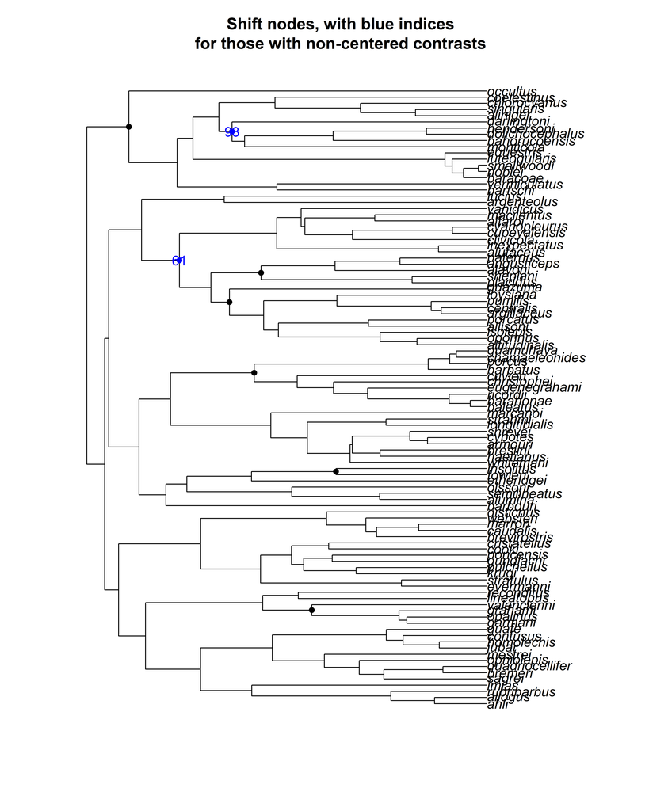

```r
layout(matrix(1, 1))
plot(eModel$tree,main="Shift nodes, with blue indices\nfor those with non-centered contrasts")
nodelabels("",shiftnode+n_tips,pch=16,frame="none") # Add n_tips for the indices of shiftnodes
# because 1:n_ntips are external nodes
nodelabels(shiftnode[5],shiftnode[5]+n_tips,pch=16,col="blue",frame="none")
nodelabels(shiftnode[6],shiftnode[6]+n_tips,pch=16,col="blue",frame="none")
```

## Mean, SD and distribution of contrasts at non-shift nodes

```r
options(digits=4)
round(colMeans(boot_table)[othernode], 3) # contrast mean at all non-shift nodes
```

```
##  [1] -0.001  0.000  0.000 -0.001  0.000  0.000 -0.001 -0.001  0.000  0.000
## [11]  0.001  0.000  0.000  0.000  0.001 -0.001 -0.001  0.000 -0.002  0.001
## [21]  0.000 -0.001  0.000 -0.001 -0.001  0.000  0.000 -0.001  0.000  0.001
## [31]  0.001  0.000  0.000  0.000  0.000  0.000  0.001  0.000 -0.001 -0.001
## [41] -0.001 -0.001  0.001 -0.001  0.000  0.000  0.000  0.001  0.000 -0.001
## [51]  0.000  0.000  0.001  0.000  0.000  0.000  0.000 -0.001  0.000  0.000
## [61] -0.001  0.000  0.001 -0.001  0.000  0.000  0.001  0.001  0.001  0.000
## [71]  0.000  0.001  0.001  0.000  0.000  0.000  0.000 -0.001  0.000  0.001
## [81]  0.000  0.000 -0.001  0.000  0.000  0.002  0.000  0.000  0.000  0.001
## [91]  0.000
```

```r
# below: proportion of negative contrasts for non-shift nodes. should be 0.5
pro0other=apply(boot_table,2,function(v){sum(v<0)/n_sim})[othernode]
round(pro0other, 3)
```

```
##  [1] 0.501 0.500 0.499 0.500 0.500 0.499 0.500 0.501 0.501 0.501 0.498
## [12] 0.498 0.499 0.499 0.498 0.500 0.501 0.500 0.503 0.497 0.501 0.501
## [23] 0.502 0.502 0.501 0.501 0.499 0.501 0.501 0.498 0.496 0.502 0.499
## [34] 0.499 0.499 0.500 0.497 0.500 0.501 0.503 0.500 0.501 0.498 0.500
## [45] 0.501 0.501 0.502 0.498 0.500 0.501 0.500 0.501 0.498 0.500 0.501
## [56] 0.498 0.499 0.499 0.500 0.500 0.501 0.501 0.500 0.502 0.499 0.500
## [67] 0.500 0.498 0.498 0.503 0.500 0.498 0.497 0.499 0.501 0.500 0.500
## [78] 0.502 0.499 0.497 0.498 0.500 0.499 0.502 0.500 0.496 0.500 0.501
## [89] 0.499 0.498 0.498
```

```r
apply(boot_table,2,sd)
```

```
##   [1] 0.2263 0.2256 0.2269 0.2273 0.2261 0.2268 0.2266 0.2264 0.2271 0.2269
##  [11] 0.2274 0.2272 0.2267 0.2271 0.2274 0.2275 0.2275 0.2268 0.2276 0.2265
##  [21] 0.2261 0.2264 0.2266 0.2275 0.2268 0.2267 0.2269 0.2275 0.2269 0.2271
##  [31] 0.2261 0.2270 0.2262 0.2263 0.2271 0.2272 0.2266 0.2268 0.2264 0.2274
##  [41] 0.2273 0.2278 0.2271 0.2277 0.2269 0.2267 0.2266 0.2266 0.2277 0.2266
##  [51] 0.2267 0.2269 0.2266 0.2266 0.2269 0.2269 0.2273 0.2278 0.2265 0.2272
##  [61] 0.2270 0.2272 0.2267 0.2268 0.2268 0.2266 0.2279 0.2265 0.2273 0.2271
##  [71] 0.2269 0.2272 0.2269 0.2265 0.2257 0.2269 0.2279 0.2268 0.2269 0.2266
##  [81] 0.2268 0.2272 0.2268 0.2269 0.2268 0.2269 0.2260 0.2271 0.2264 0.2270
##  [91] 0.2267 0.2274 0.2272 0.2269 0.2274 0.2272 0.2270 0.2271 0.2267 0.2269
```

```r
apply(boot_table,2,sd)[othernode]      # contrast SD at all non-shift nodes
```

```
##  [1] 0.2263 0.2256 0.2269 0.2273 0.2261 0.2268 0.2266 0.2264 0.2271 0.2269
## [11] 0.2274 0.2272 0.2267 0.2271 0.2274 0.2275 0.2275 0.2276 0.2265 0.2261
## [21] 0.2264 0.2266 0.2275 0.2268 0.2267 0.2269 0.2275 0.2269 0.2271 0.2261
## [31] 0.2270 0.2262 0.2263 0.2271 0.2272 0.2266 0.2268 0.2264 0.2274 0.2278
## [41] 0.2271 0.2277 0.2269 0.2267 0.2266 0.2266 0.2277 0.2266 0.2269 0.2266
## [51] 0.2266 0.2269 0.2269 0.2273 0.2278 0.2265 0.2272 0.2272 0.2268 0.2268
## [61] 0.2266 0.2279 0.2265 0.2273 0.2271 0.2269 0.2269 0.2265 0.2257 0.2269
## [71] 0.2279 0.2268 0.2269 0.2266 0.2268 0.2272 0.2268 0.2268 0.2269 0.2260
## [81] 0.2271 0.2264 0.2270 0.2267 0.2274 0.2269 0.2274 0.2272 0.2270 0.2271
## [91] 0.2267
```

```r
convar = mean(apply(boot_table,2,var)) # constrast variance, assumed to be the same at all nodes
```

The distribution of contrasts seems normal for all nodes (based on histograms that are not shown).

The contrast standard deviation seems to be equal at all nodes (up to simulation stochasticity), but incorrect because we expected the contrast variance to be `sigma2 =` $0.0625$. An estimate of their common variance is quite different: `convar =` $0.0515$, with square-root (SD) of $0.2269$.

## Phylogenetic position of nodes with non-centered contrasts

```r
prop.below0 = apply(boot_table,2,function(v){sum(v<0)/n_sim}) # proportion of negative contrasts
round(prop.below0,2)
```

```
##   [1] 0.5 0.5 0.5 0.5 0.5 0.5 0.5 0.5 0.5 0.5 0.5 0.5 0.5 0.5 0.5 0.5 0.5
##  [18] 0.5 0.5 0.5 0.5 0.5 0.5 0.5 0.5 0.5 0.5 0.5 0.5 0.5 0.5 0.5 0.5 0.5
##  [35] 0.5 0.5 0.5 0.5 0.5 0.5 0.5 0.5 0.5 0.5 0.5 0.5 0.5 0.5 0.5 0.5 0.5
##  [52] 0.5 0.5 0.5 0.5 0.5 0.5 0.5 0.5 0.5 0.5 0.5 0.5 0.5 0.5 0.5 0.5 0.5
##  [69] 0.5 0.5 0.5 0.5 0.5 0.5 0.5 0.5 0.5 0.5 0.5 0.5 0.5 0.5 0.5 0.5 0.5
##  [86] 0.5 0.5 0.5 0.5 0.5 0.5 0.5 0.5 0.5 0.5 0.5 0.5 0.5 0.5 0.5
```

```r
weird0.3 = which(prop.below0 < .3) # indices of nodes with a high mean
weird0.3
```

```
## integer(0)
```

```r
weird0.7= which( prop.below0 > .7) # indices of nodes with a low mean
weird0.7
```

```
## integer(0)
```

```r
#plot(eModel$tree, main="Nodes with a proportion of negative contrasts < 0.3 or > 0.7")
#nodelabels("",weird0.3+n_tips,pch=16,col="blue",frame = "none")
#nodelabels("",weird0.7+n_tips,pch=16,col="green",frame = "none")
#mtext("Blue: nodes with 30% or fewer negative contrasts.
#Green: nodes with 70% or more negative contrasts.",side=1,pch=16,line=2)
```